# Northcott Medulloblastoma: Clustering

**CCDL 2018**

In this notebook, we’ll be exploring hierarchical clustering and a variant, consensus clustering. We’ll often use hierarchical clustering to get a sense of what groupings and patterns exist in our data.

## Libraries and functions

```r
# package for making heatmaps
library(ComplexHeatmap)
# package for consensus clustering
library(ConsensusClusterPlus)
```

```r
# magrittr pipe
`%>%` <- dplyr::`%>%`
```

## Directories and files

```r
# directory for the data
data_dir <- file.path("data", "GSE37382")
# directory where we will save any kind of results
results_dir <- "results"
if (!dir.exists(results_dir)) {
  dir.create(results_dir, recursive = TRUE)
}
# directory where we will save any plots
plots_dir <- "plots"
if (!dir.exists(plots_dir)) {
  dir.create(plots_dir, recursive = TRUE)
}
# expression data that we prepped in the first notebook
exprs_file <- file.path(data_dir, "GSE37382_SCAN_symbol_mean_agg.tsv")
# tab-delimited file of sample data that someone has already cleaned for us!
meta_file <- file.path(data_dir, "GSE37382_cleaned_metadata.tsv")
```

**Output**

```r
# heatmap with annotation bars
heatmap_file <- file.path(plots_dir, "GSE37382_sample_sample_heatmap.pdf")
# consensus clustering results
cc_file <- file.path(results_dir, "GSE37382_consensus_clustering_results.RDS")
# labels for k = 5
cc_tsv <- file.path(results_dir, "GSE37382_k5_labels.tsv")
```

## Read in data

### Expression data

Read in the expression data with `data.table`.

```r
exprs_df <- data.table::fread(exprs_file, data.table = FALSE)
```

We’ll need a matrix of expression data where the `rownames` are the gene symbols to do the clustering.

```r
exprs_mat <- as.matrix(tibble::column_to_rownames(exprs_df, "SYMBOL"))
```

### Sample metadata

Read in the metadata with `readr`.

```r
sample_meta_df <- readr::read_tsv(meta_file)
```

Let’s see what that metadata `data.frame` contains.

```r
sample_meta_df
```

| source_name | sample_identifier | tissue_type | age | histology | sex | subgroup |
| --- | --- | --- | --- | --- | --- | --- |
| GSM917295 | MB-1366 | Primary medulloblastoma | 5.8 | Classic | M | Group 4 |
| GSM917294 | MB-1365 | Primary medulloblastoma | 13.0 | Classic | M | Group 4 |
| GSM917293 | MB-1361 | Primary medulloblastoma | 4.2 | Classic | M | Group 4 |
| GSM917292 | MB-1357 | Primary medulloblastoma | 9.5 | Classic | F | Group 4 |
| GSM917291 | MB-1350 | Primary medulloblastoma | 15.0 | Classic | M | Group 4 |
| GSM917290 | MB-1345 | Primary medulloblastoma | 12.0 | Classic | F | Group 4 |
| GSM917289 | MB-1341 | Primary medulloblastoma | 7.0 | Classic | M | Group 4 |
| GSM917288 | MB-1336 | Primary medulloblastoma | 9.0 | Classic | F | Group 4 |
| GSM917287 | MB-1327 | Primary medulloblastoma | 6.0 | Desmoplastic | M | Group 4 |
| GSM917286 | MB-1323 | Primary medulloblastoma | 9.0 | Classic | M | Group 4 |

[output cut: 275 more lines]

## Relationship between samples

In this notebook, we’ll look at the relationship between samples, but we can use hierarchical clustering for looking at the relationship between genes.

First thing we’ll do is calculate the Pearson correlation between samples to get a correlation matrix. This will tell us how similar in expression values the samples are to one another.

```r
set.seed(12345)
```

### Correlation

```r
pearson_mat <- cor(exprs_mat, method = "pearson")
```

Let’s see if there’s some structure in the transcriptome data! We’ll use the `ComplexHeatmap` package we loaded up top.

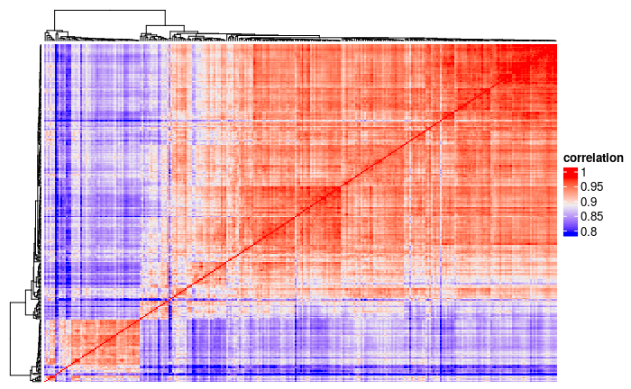

```r
Heatmap(pearson_mat,
        clustering_distance_rows = "pearson",
        clustering_method_rows = "average",
        clustering_distance_columns = "pearson",
        clustering_method_columns = "average",
        show_column_names = FALSE,
        show_row_names = FALSE,
        heatmap_legend_param = list(title = "correlation"))
```

We can see that there are at least two groups of samples. Does this structure correspond to subgroup or histology?

### Annotation bars

We have labels for these samples in `sample_meta_df`. We can layer this information onto the heatmap using annotation bars, but first we’ll have to format it for use with [`ComplexHeatmap`](http://www.bioconductor.org/packages/release/bioc/vignettes/ComplexHeatmap/inst/doc/s1.introduction.html#toc_0). The `rownames` of the `data.frame` used for annotation will need to correspond to the sample names, which are the `colnames` of `exprs_mat`.

```r
annotation_df <- sample_meta_df %>%
  # annotation_df is actually a tibble, but we'll want it to be a data.frame
  as.data.frame() %>%
  # selecting the three columns of interest -- the sample name, the histology
  # group and the subgroup
  dplyr::select(source_name, histology, subgroup) %>%
  # we want the sample names that are in the source_name column to be the
  # rownames rather than their own column
  tibble::column_to_rownames(var = "source_name")
```

Is the order of samples the same?

```r
all.equal(rownames(annotation_df), colnames(pearson_mat))
```

```
[1] "284 string mismatches"
```

No, so we should reorder the rows of `annotation_df`.

```r
annotation_df <- annotation_df[colnames(pearson_mat), ]
all.equal(rownames(annotation_df), colnames(pearson_mat))
```

```
[1] TRUE
```

Set up the colors to be used for the annotation bar. We’ll use greys for the histology and a colorblind friendly palette for the subgroups.

```r
histology_colors <- RColorBrewer::brewer.pal(9, "Greys")
annotation_colors <- list(
  histology = c("Classic" = histology_colors[1],
                "Desmoplastic" = histology_colors[2],
                "LCA" = histology_colors[3],
                "MBEN" = histology_colors[4],
                "medulloblastoma" = histology_colors[5],
                "N/A" = histology_colors[6]),
  subgroup = c("SHH" = "#00BFFF", "Group 3" = "#FFC125",
               "Group 4" = "#00CD66")
)
```

We’ll need to make a separate annotation object with the `HeatmapAnnotation` function in `ComplexHeatmap`. (You can find a vignette about annotations [here](http://www.bioconductor.org/packages/release/bioc/vignettes/ComplexHeatmap/inst/doc/s4.heatmap_annotation.html)).

```r
ha_column <- HeatmapAnnotation(df = annotation_df, col = annotation_colors)
```

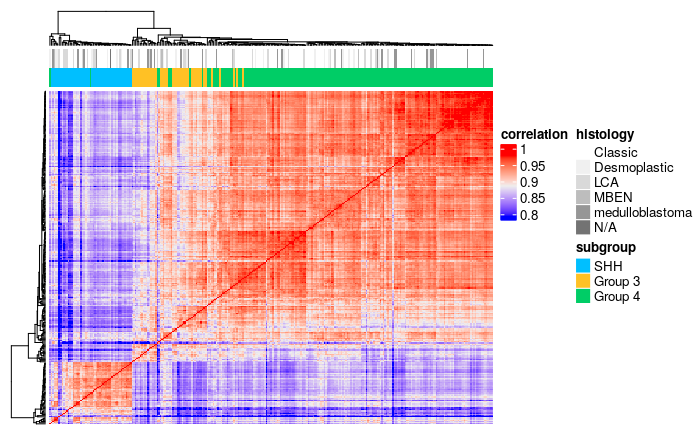

```r
Heatmap(pearson_mat,
        clustering_distance_rows = "pearson",
        clustering_method_rows = "average",
        clustering_distance_columns = "pearson",
        clustering_method_columns = "average",
        show_column_names = FALSE,
        show_row_names = FALSE,
        heatmap_legend_param = list(title = "correlation"),
        top_annotation = ha_column)
```

It looks like SHH samples are distinct from Group 3 and Group 4, which are more similar.

Save heatmap to file!

```r
pdf(heatmap_file, width = 7, height = 5)
Heatmap(pearson_mat,
        clustering_distance_rows = "pearson",
        clustering_method_rows = "average",
        clustering_distance_columns = "pearson",
        clustering_method_columns = "average",
        show_column_names = FALSE,
        show_row_names = FALSE,
        heatmap_legend_param = list(title = "correlation"),
        top_annotation = ha_column)
dev.off()
```

## Consensus clustering

Hierarchical clustering is what we call a “weak” clustering method – we should not take the groups it finds as “law.” We can use a method called consensus clustering to find the “consensus” across multiple runs of the algorithm using a resampling procedure.

We’ll use the package [`ConsensusClusterPlus`](https://bioconductor.org/packages/release/bioc/html/ConsensusClusterPlus.html) that we loaded up top.

```
end fraction
```

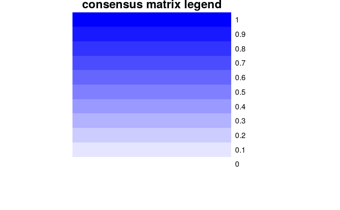

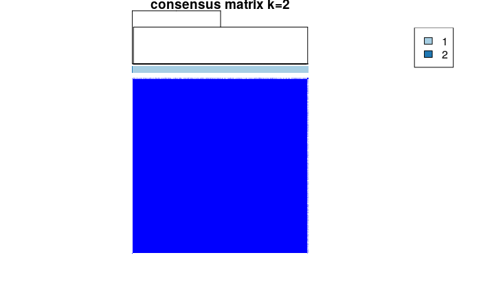

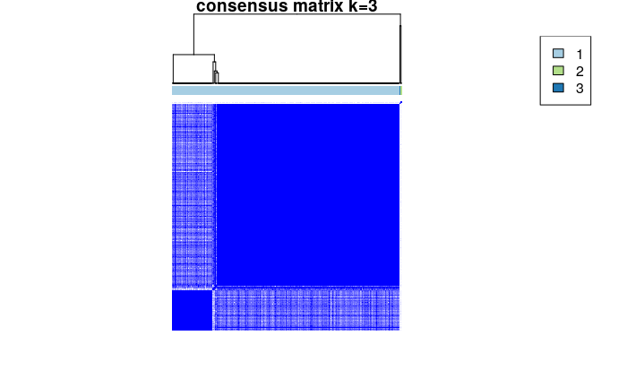

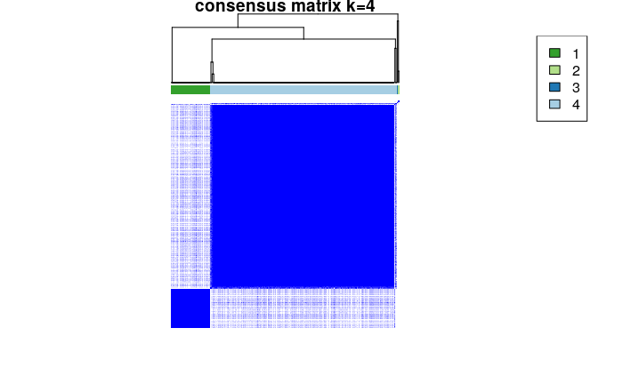

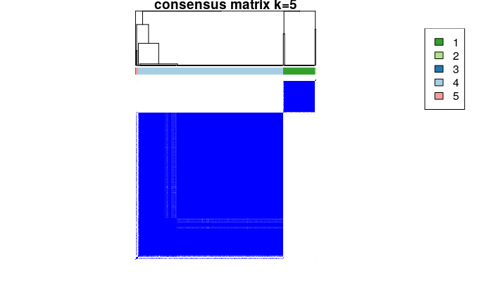

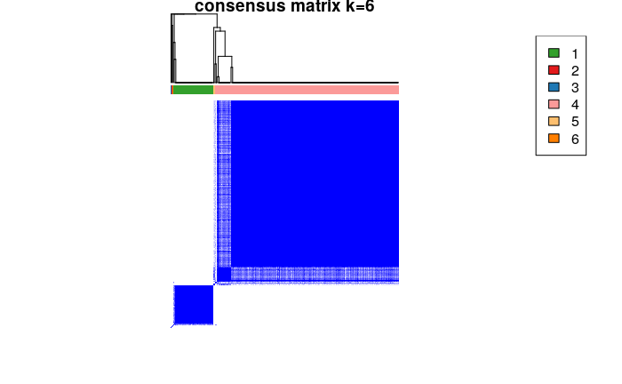

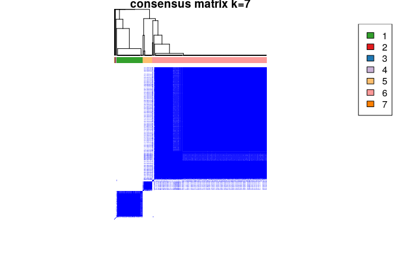

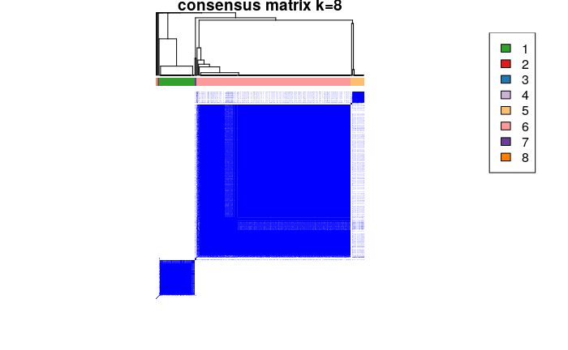

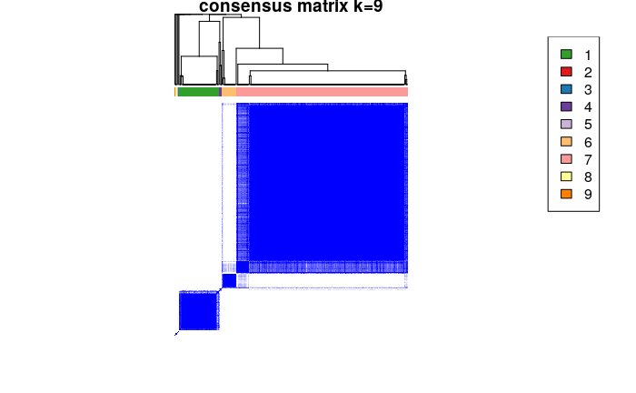

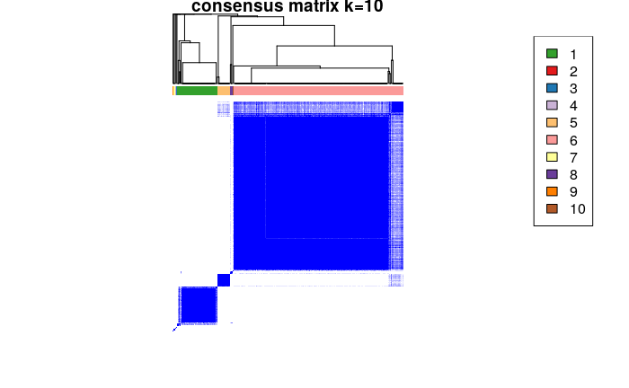

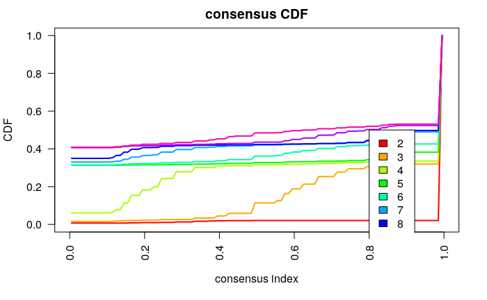

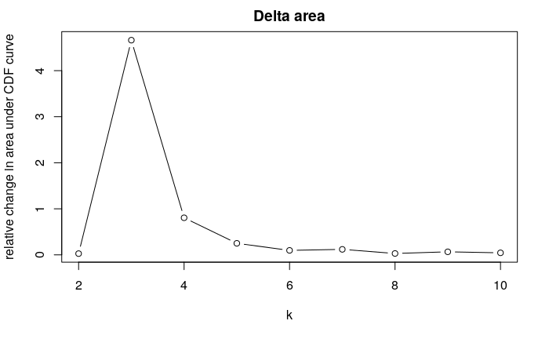

[1 more figures not shown]

```r
consensus_cluster_results <- ConsensusClusterPlus(d = exprs_mat, maxK = 10, seed = 12345)
```

Looks like there are probably two groups with some outliers, let’s look at `k = 5`.

```r
# this is how we get the class labels out of the results -- note that
# the cluster numbers are arbitrary
head(consensus_cluster_results[[5]]$consensusClass)
```

```
GSM917011 GSM917014 GSM917018 GSM917016 GSM917015 GSM917017
        1         1         1         1         1         1
```

```r
# now let's save the class labels to an object
k5_labels <- consensus_cluster_results[[5]]$consensusClass
```

```r
# create a table to display the number of samples associated with each subgroup for each of the clusters
table(annotation_df[names(k5_labels), "subgroup"], k5_labels)
```

```
         k5_labels
            1   2   3   4   5
  Group 3   0   0   0  46   0
  Group 4   1   1   0 183   3
  SHH      49   1   1   0   0
```

Looks like `Group 3` and `Group 4` cluster together, separate from `SHH`. We’ll save these results into the results directory.

```r
readr::write_rds(consensus_cluster_results, path = cc_file)
```

Let’s also save the cluster labels in a data.frame so we can use them in downstream analyses.

```r
# get a data.frame with 1 column that has the cluster labels
cc_df <- data.frame(Cluster = k5_labels)
# the sample names are the rownames, we'll want them as a column
cc_df <- tibble::rownames_to_column(cc_df, var = "Sample")
head(cc_df)
```

|  | Sample | Cluster |
| --- | --- | --- |
| 1 | GSM917011 | 1 |
| 2 | GSM917014 | 1 |
| 3 | GSM917018 | 1 |
| 4 | GSM917016 | 1 |
| 5 | GSM917015 | 1 |
| 6 | GSM917017 | 1 |

Write these results to file.

```r
readr::write_tsv(cc_df, path = cc_tsv)
```